# Chapter#3: Logistic regression

## Predictive power of my model

```r
# predict() the probability of high_use
probabilities <- predict(m, type = "response")

# add the predicted probabilities to 'studentAlc'
studentAlc <- mutate(studentAlc, probability = probabilities)

# use the probabilities to make a prediction of high_use
studentAlc <- mutate(studentAlc, prediction = probability > 0.5)

# see the last ten original classes, predicted probabilities, and class predictions
select(studentAlc, G3, absences, goout, health, high_use, probability, prediction) %>% tail(10)
```

```
##     G3 absences goout health high_use probability prediction
## 361  2        7     3      3     TRUE  0.34728425      FALSE
## 362 11        3     3      3     TRUE  0.21838164      FALSE
## 363 10        2     1      5     TRUE  0.07895958      FALSE
## 364 16        4     4      2     TRUE  0.30564438      FALSE
## 365 12        3     2      3    FALSE  0.11524638      FALSE
## 366  8        4     3      3     TRUE  0.25252304      FALSE
## 367 14        0     2      5    FALSE  0.11559977      FALSE
## 368  9        4     4      5     TRUE  0.47613178      FALSE
## 369 10        8     4      2     TRUE  0.42751451      FALSE
## 370  0        0     2      5    FALSE  0.18309931      FALSE
```

```r
# tabulate the target variable versus the predictions
table(high_use = studentAlc$high_use, prediction = studentAlc$prediction)
```

```
##         prediction
## high_use FALSE TRUE
##    FALSE   233   26
##    TRUE     65   46
```

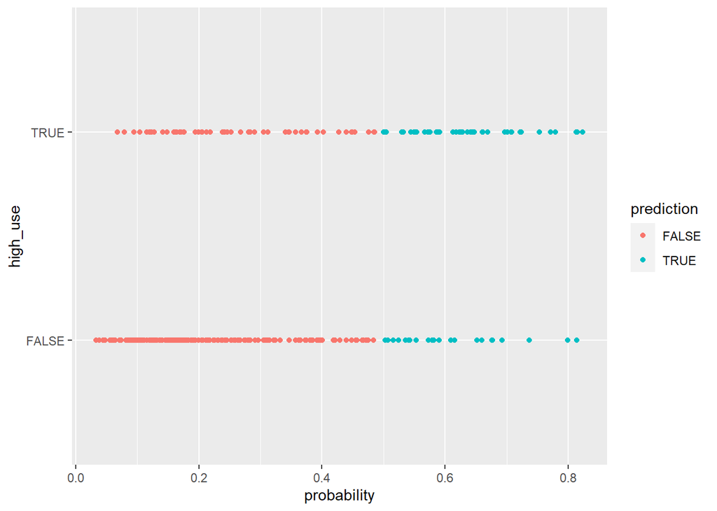

```r
# initialize a plot of 'high_use' versus 'probability' in 'studentAlc'
g <- ggplot(studentAlc, aes(x = probability, y = high_use, col = prediction))

# define the geom as points and draw the plot
g + geom_point()
```

```r
# tabulate the target variable versus the predictions
table(high_use = studentAlc$high_use, prediction = studentAlc$prediction) %>% prop.table %>% addmargins
```

```
##         prediction
## high_use      FALSE       TRUE        Sum
##    FALSE 0.62972973 0.07027027 0.70000000
##    TRUE  0.17567568 0.12432432 0.30000000
##    Sum   0.80540541 0.19459459 1.00000000
```

```r
# define a loss function (average prediction error)
loss_func <- function(class, prob) {
  n_wrong <- abs(class - prob) > 0.5
  mean(n_wrong)
}

# call loss_func to compute the average number of wrong predictions in the (training) data
loss_func(class = studentAlc$high_use, prob = studentAlc$probability)
```

```
## [1] 0.2459459
```

The goal of a loss function is to get a small number as possible. The loss function here is around 0.25. Therefore, the model does not predict correctly 25% of the time. The model perform better than the simple guessing strategy.

## 10-fold cross-validation

### Bonus

```r
# K-fold cross-validation
library(boot)
cv <- cv.glm(data = studentAlc, cost = loss_func, glmfit = m, K = 10)

# average number of wrong predictions in the cross validation
cv$delta[1]
```

```
## [1] 0.2513514
```

The result of the cross-validation (K=10) is similar to the previous result of the loss function. My model seems to produce a similar result as the model found in DataCamp.

### Super Bonus

#### Many variables

```r
# New model with many variables
m <- glm(high_use ~ G3 + absences + goout + health + studytime + failures + freetime + famrel, data = studentAlc, family = "binomial")

# compute odds ratios (OR)
OR <- coef(m) %>% exp

# compute confidence intervals (CI)
CI <- confint(m) %>% exp
# print out the odds ratios with their confidence intervals
cbind(OR, CI)
```

```
##                    OR      2.5 %    97.5 %
## (Intercept) 0.1112482 0.01462431 0.7969864
## G3          1.0004152 0.91884143 1.0909553
## absences    1.0707813 1.02620258 1.1197948
## goout       2.0410506 1.59736372 2.6461037
## health      1.1744770 0.97382116 1.4240680
## studytime   0.6138411 0.43227534 0.8559677
## failures    1.3512750 0.85082981 2.1704783
## freetime    1.1869927 0.89658690 1.5765989
## famrel      0.6655703 0.49995249 0.8817370
```

```r
# predict() the probability of high_use
probabilities <- predict(m, type = "response")

# add the predicted probabilities to 'studentAlc'
studentAlc <- mutate(studentAlc, probability = probabilities)

# use the probabilities to make a prediction of high_use
studentAlc <- mutate(studentAlc, prediction = probability > 0.5)

# define a loss function (average prediction error)
loss_func <- function(class, prob) {
  n_wrong <- abs(class - prob) > 0.5
  mean(n_wrong)
}

# call loss_func to compute the average number of wrong predictions in the (training) data
loss_func(class = studentAlc$high_use, prob = studentAlc$probability)
```

```
## [1] 0.2324324
```

```r
# K-fold cross-validation
library(boot)
cv <- cv.glm(data = studentAlc, cost = loss_func, glmfit = m, K = 10)

# average number of wrong predictions in the cross validation
cv$delta[1]
```

```
## [1] 0.2594595
```

#### New model with 2 variable only

```r
# New model with 2 variables
m <- glm(high_use ~ absences + goout, data = studentAlc, family = "binomial")

# compute odds ratios (OR)
OR <- coef(m) %>% exp

# compute confidence intervals (CI)
CI <- confint(m) %>% exp
# print out the odds ratios with their confidence intervals
cbind(OR, CI)
```

```
##                     OR      2.5 %     97.5 %
## (Intercept) 0.02644199 0.01082308 0.06045431
## absences    1.07930582 1.03477610 1.13034717
## goout       2.08298255 1.66258410 2.64170298
```

```r
# predict() the probability of high_use
probabilities <- predict(m, type = "response")

# add the predicted probabilities to 'studentAlc'
studentAlc <- mutate(studentAlc, probability = probabilities)

# use the probabilities to make a prediction of high_use
studentAlc <- mutate(studentAlc, prediction = probability > 0.5)

# define a loss function (average prediction error)
loss_func <- function(class, prob) {
  n_wrong <- abs(class - prob) > 0.5
  mean(n_wrong)
}

# call loss_func to compute the average number of wrong predictions in the (training) data
loss_func(class = studentAlc$high_use, prob = studentAlc$probability)
```

```
## [1] 0.2378378
```

```r
# K-fold cross-validation
library(boot)
cv <- cv.glm(data = studentAlc, cost = loss_func, glmfit = m, K = 10)

# average number of wrong predictions in the cross validation
cv$delta[1]
```

```
## [1] 0.2405405
```

It seems that the result is not greatly improved when going from many variables to only 2 variables.